# Assignment 9. Data visualization

Anabel Berjón Sánchez

11/11/2020

```r
library(tidyverse)
library(lubridate)
library(legislatoR)
library(data.table)
library(dotwhisker)
library(broom)
library(stargazer)
library(eeptools)
library(scales)
```

## 1. Fetching data on members of the 115th United States Congress

The `legislatoR` package (https://github.com/saschagobel/legislatoR) provides access to the Comparative Legislators Database (CLD). The CLD includes political, sociodemographic, career, online presence, public attention, and visual information (organized in separate tables, very similar to a proper database structure) for over 45,000 contemporary and historical politicians from ten countries.

Install the package (either from CRAN or GitHub) and use it to compile the following data into one dataset:

1. The political data for the 115th session of the US House of Representatives
2. The data on daily user traffic on individual Wikipedia biographies (use it to compute the average number of daily page views per representative between January 3, 2017 and January 3, 2019 and match the variable to the dataset)
3. The information on the total number of sessions served by representative (compute it by counting the number of entries in the political table when grouped by representative).

```r
#a)The data for the 115th session of the US House of Representatives
usa_politicians<-get_core(legislature = "usa_house")
usa_politicians_subset <- get_political(legislature = "usa_house")%>%
  filter(session==115)

usa_politicians_115<-right_join(usa_politicians, usa_politicians_subset, by="pageid")

#b)Add Wikidataid to 'Traffic' table for the US House of Senate
usa_traf <- get_traffic(legislature = "usa_house")
usa_traf1 <- subset(usa_traf, date > "2017-01-03" & date < "2019-01-03")
usa_traf2<- setDT(usa_traf1)[ , .(avg_traffic = mean(traffic)), by = pageid]
usa_traffic<- merge(usa_politicians_115, usa_traf2, by = "pageid")


#c)The data for the total number of sessions
usa_sessions<-get_political(legislature="usa_house")%>%
  count(pageid, sort = TRUE, name = "session_count")

#Join data sets
usa_house_final<-left_join(usa_traffic,usa_sessions, by= "pageid")
```

## 2. Exploring the dataset

Explore the dataset using visual means, following the guidelines of good visualization. Provide three different visualizations. One visualization is entirely up to you. The two others should give any two of the following:

1. gender or ethnicity distribution by party (Democrat/Republican; ignore the others)
2. age distribution by state in which the representative’s district is located (limit to states with 10+ representatives)
3. top 10 representatives according to average daily page views
4. log mean page views vs. the number of sessions served

Transform the variables if needed (e.g., categorize continuous variables, pool residual categories into one, etc.).

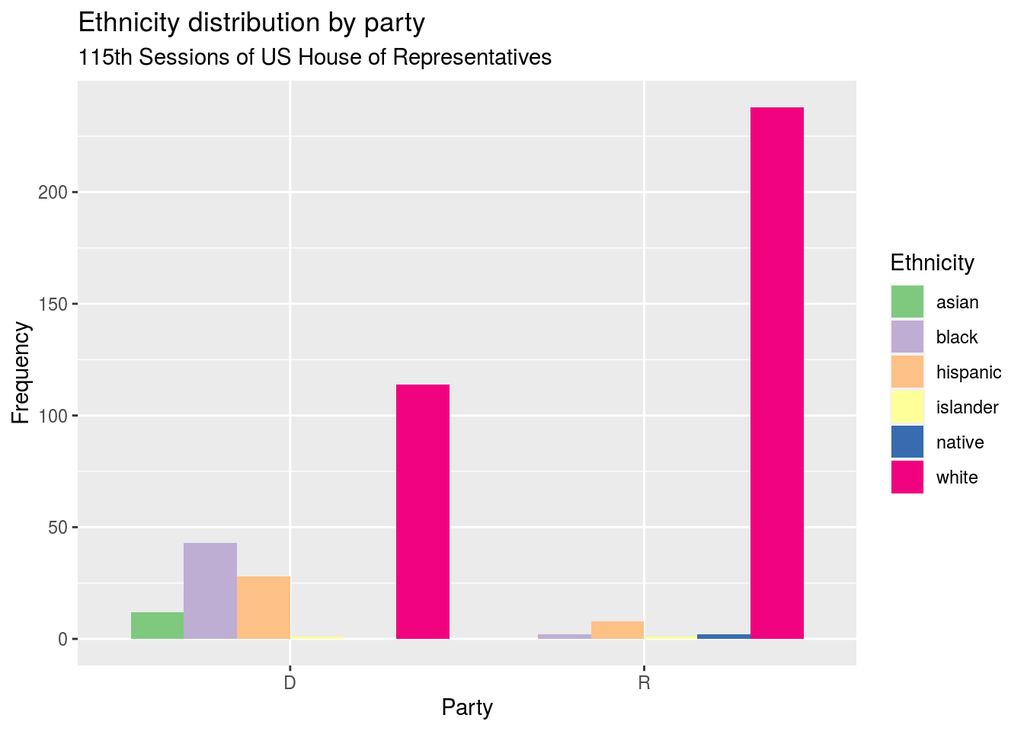

```r
#A: Ethnicity distribution by party

#Distribution of ethnicity
ethnicity_distribution<-table(usa_house_final$ethnicity, usa_house_final$party)
ethnicity_distribution<-as.data.frame(ethnicity_distribution)
#Renaming variables
names(ethnicity_distribution)[1]<-paste("Ethnicity")
names(ethnicity_distribution)[2]<-paste("Party")

#Plotting ethnicity
plot_ethnicity<-ggplot(subset(ethnicity_distribution,Party %in% c("R" , "D")), aes(x=Party, y=Freq, fill = Ethnicity)) +
   geom_bar(stat="identity", position="dodge")+
    scale_fill_brewer(palette = "Accent") +
  labs(title = "Ethnicity distribution by party",
       subtitle = "115th Sessions of US House of Representatives")+
  labs(colour = "Ethnicity",
       x = "Party",
       y = "Frequency")

plot_ethnicity
```

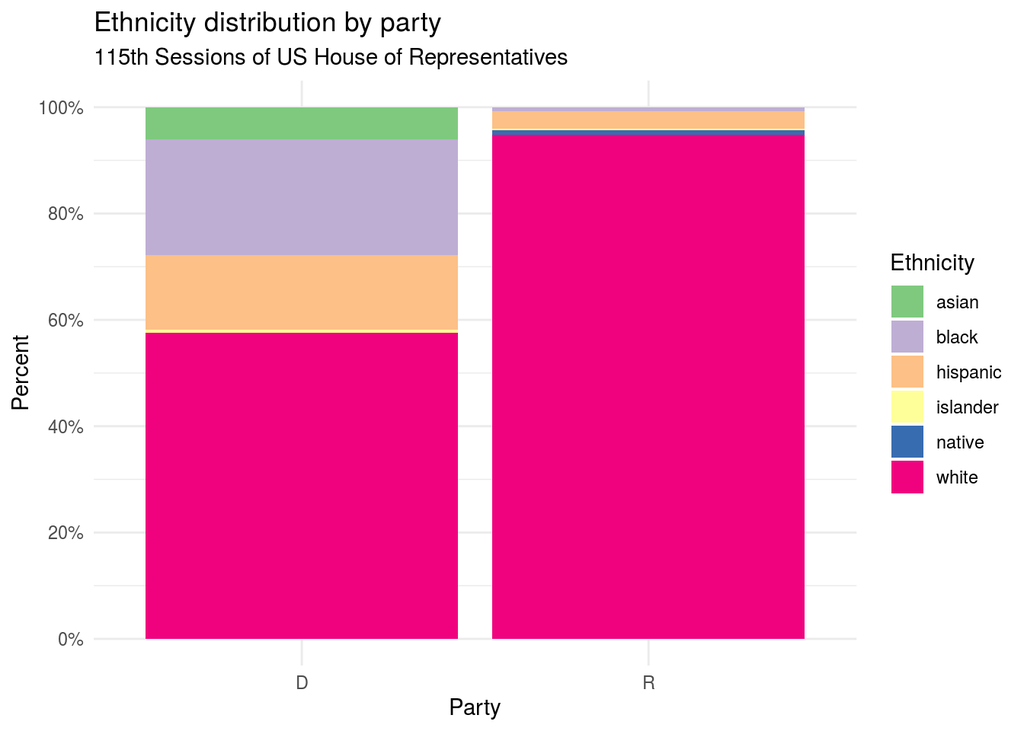

```r
#Plot with percentages
ethnicityplot <- subset(usa_house_final, (party == "D" | party == "R"))

eth_plot<- ggplot(ethnicityplot[!is.na(ethnicityplot$ethnicity),],
  aes(x = factor(party), fill = factor(ethnicity))) +
  geom_bar(position = "fill") +
  scale_y_continuous(breaks = seq(0, 1, .2),
                     label = percent) +
 scale_fill_brewer(palette = "Accent") +
  labs(y = "Percent",
       fill = "Ethnicity",
       x = "Party",
       title = "Ethnicity distribution by party",
       subtitle = "115th Sessions of US House of Representatives") +
  theme_minimal()

eth_plot
```

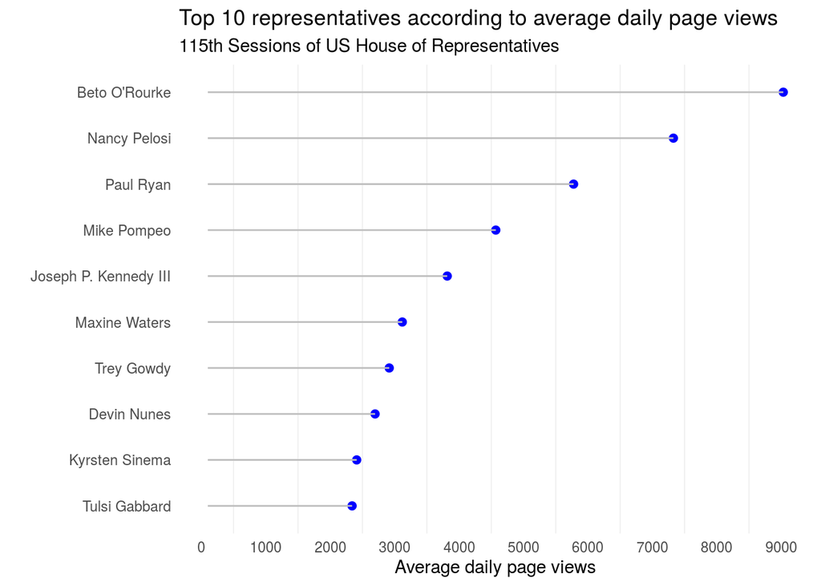

```r
#C: Top 10 representatives according to average daily page views
# Preparing the data for the plot
library(scales)
topviewplot <- usa_house_final %>%
                arrange(desc(avg_traffic)) %>%
                slice_head(n = 10)
# Plotting Dot Chart
top10<- ggplot(topviewplot,
      aes(x = avg_traffic, y = reorder(name, avg_traffic))) +
      geom_point(color="blue", size = 2) +
      geom_segment(aes(x = 100, xend = avg_traffic,
      y = reorder(name, avg_traffic),
      yend = reorder(name, avg_traffic)), color = "grey") +
      labs (x = "Average daily page views",
      y = "",
      title = "Top 10 representatives according to average daily page views",
      subtitle = "115th Sessions of US House of Representatives") +
      theme_minimal() +
      theme(panel.grid.major = element_blank()) +
      scale_x_continuous(breaks = seq(0, 12000, 1000))
top10
```

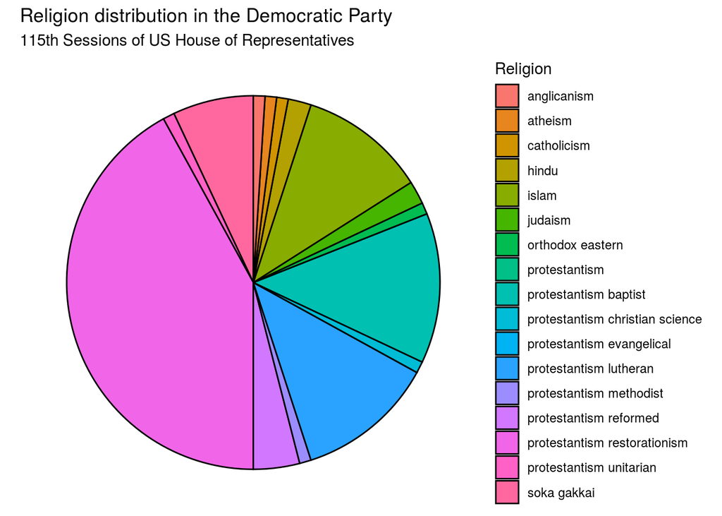

```r
#OPTIONAL: Pie Chart for religion distribution

#Distribution of religion
religion_distribution<-table(usa_house_final$religion, usa_house_final$party)
religion_distribution<-as.data.frame(religion_distribution)
#Renaming variables
names(religion_distribution)[1]<-paste("Religion")
names(religion_distribution)[2]<-paste("Party")

#Filter data by democrats
democrats<-subset(religion_distribution,Party=="D")
republicans<-subset(religion_distribution,Party=="R")

#Pie Chart for democrats
democrats_pie <- democrats%>%
    count(Religion) %>%
    arrange(desc(Religion)) %>%
    mutate(prop = round(democrats$Freq * 100 / sum(democrats$Freq), 1),lab.ypos = cumsum(prop) - 0.5  *prop)

democrats_pie_plot<- ggplot(democrats_pie,
         aes(x = "",
             y = prop,
             fill = Religion)) +
    geom_bar(width = 1,
             stat = "identity",
             color = "black") +
    coord_polar("y",
                start = 0,
                direction = -1) +
  labs(title = "Religion distribution in the Democratic Party",
       subtitle = "115th Sessions of US House of Representatives") +
    theme_void()
democrats_pie_plot
```

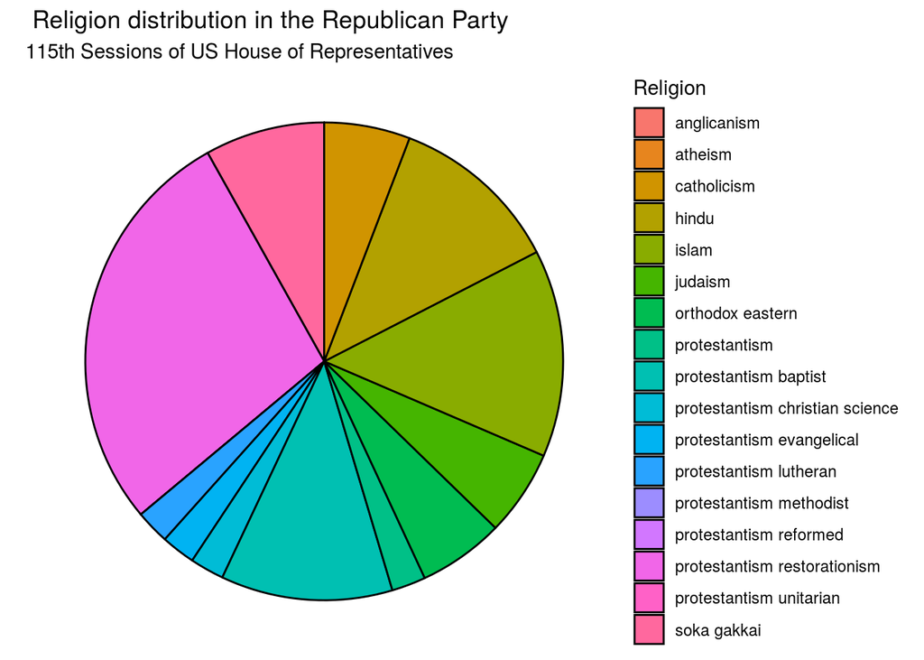

```r
#Pie Chart for republicans
republicans_pie<- republicans%>%
    count(Religion) %>%
    arrange(desc(Religion)) %>%
    mutate(prop = round(republicans$Freq * 100 / sum(republicans$Freq), 1),lab.ypos = cumsum(prop) - 0.5  *prop)

republicans_pie_plot<- ggplot(republicans_pie,
         aes(x = "",
             y = prop,
             fill = Religion)) +
    geom_bar(width = 1,
             stat = "identity",
             color = "black") +
    coord_polar("y",
                start = 0,
                direction = -1) +
  labs(title = " Religion distribution in the Republican Party",
       subtitle = "115th Sessions of US House of Representatives") +
    theme_void()
republicans_pie_plot
```

## 3. Modeling page views

Finally, model the log number of mean page views as a function of the following variables:

- number of sessions served,
- party membership (Democrat/Republican/Independent)
- key political position (a dummy which takes the value 1 if the representative is one of the following: speaker, majority/minority leader/whip)
- age
- gender
- ethnicity (white/non-white)

A linear model is just fine. Present the results of your model in both a table and a coefficient plot!

```r
# Adding the data
# Filtering the data for parties, D,R and Indepent
party_model <- subset(usa_house_final, party == "D" | party == "R" |
                      party == "Independent")

#Ethnicity (white/non-white)
nonwhite <- party_model[-grep("white", party_model$ethnicity),]
nonwhite$ethnicity <- "non-white"
white <- party_model[grep("white", party_model$ethnicity),]
eth_model <- rbind(white, nonwhite)

# Including political position
position_model <- eth_model %>% mutate(
  keypp = case_when(
    house_speaker == TRUE ~ 1,
    house_majority_leader == TRUE ~ 1,
    house_majority_whip == TRUE ~ 1,
    house_minority_leader == TRUE ~ 1,
    house_minority_whip == TRUE ~ 1,
  ))
position_model$keypp[is.na(position_model$keypp)] <- 0

# Adding age
final_model <- position_model[c("avg_traffic", "session_count" ,"party", "keypp", "birth", "sex", "ethnicity")]
final_model$birth <- as.Date(final_model$birth)
final_model <- na.omit(final_model)
final_model$age <- floor(age_calc(final_model$birth, units = "years"))


# Model fitting
model1<- lm(log(avg_traffic) ~ session_count + party + keypp +
            age + sex + ethnicity, data = final_model)

model1
```

Call: lm(formula = log(avg_traffic) ~ session_count + party + keypp + age + sex + ethnicity, data = final_model)

Coefficients: (Intercept) session_count partyIndependent partyR  
6.74539 0.04258 -0.67343 -0.01157  
keypp age sexmale ethnicitywhite  
2.32999 -0.02421 -0.37273 -0.01736

```r
stargazer(model1, title = "Model 1 Results",
          dep.var.labels=c("Log number of mean page views"),
          covariate.labels=c("Number of sessions served", "Party",
          "Key political position", "Age", "Gender", "Ethnicity"),
          type = "html")
```

**Model 1 Results**

[output not shown]

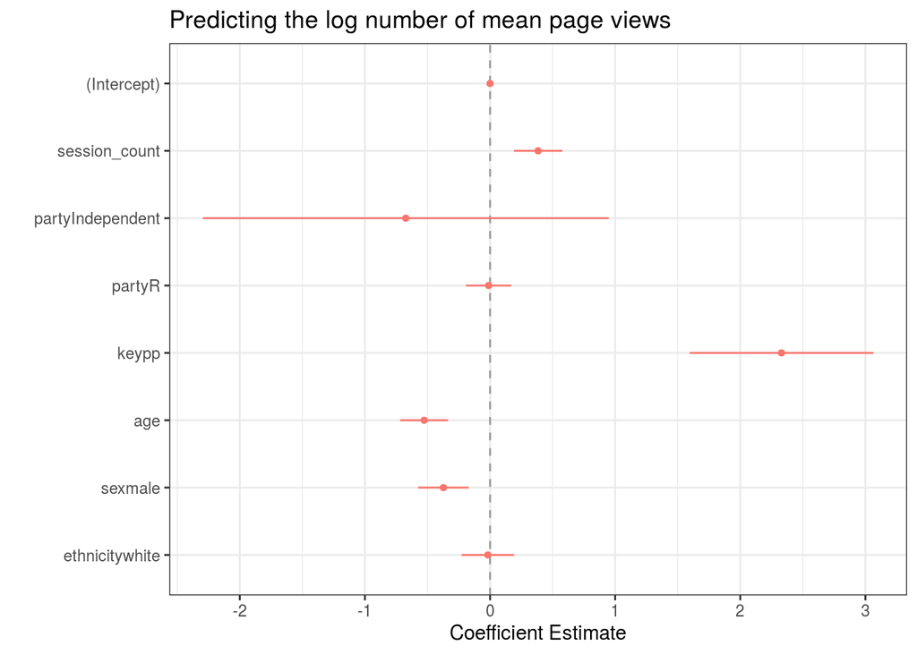

```r
#Plot
model_plot<- dwplot(model1, show_intercept = TRUE,
      vline = geom_vline(xintercept = 0,
      colour = "grey60", linetype = 2)) +
      theme_bw() + xlab("Coefficient Estimate") +
      ggtitle("Predicting the log number of mean page views") +
      theme(legend.position = "none")
model_plot
```